# Lecture 11: Multiple regression, logistic regression and k-nearest neighbours

ØKA2015 Applied Data Science, University of Inland Norway

Touseef Hameed

3 November 2026

# 1 What this document is

This is Lecture 11 as a written tutorial, in the same order as the script `lecture11_models.R`. It follows *Business Analytics* (Camm et al.), Chapters 8.4 and 8.5, 10.2 and 10.3, and 11.1 to 11.4, and Chapter 5 of *Tidyverse Skills for Data Science* (Wright et al.). Open the `.Rmd` file in RStudio and press **Knit** to rebuild this PDF.

In Lecture 10 you fitted a straight line with one $x$: $y = \alpha + \beta x + \varepsilon$. Today you use several $x$ variables, then predict a $y$ that is only yes or no, and then predict from the most similar cases with k-nearest neighbours, checked on data the model has not seen.

# 2 Packages and the data

`install.packages()` is needed once per computer; `library()` every session. Two packages are new today: `car` gives `vif()`, and `class` gives `knn()` (it comes with R).

```r
install.packages("tidyverse")        # once per computer. Installed in Lecture 3
install.packages("broom")            # once per computer. Installed in Lecture 10
install.packages("GGally")           # once per computer. Installed in Lecture 7
install.packages("car")              # once per computer. New today
install.packages("class")            # once per computer. New today
```

```r
library(tidyverse)                   # loads ggplot2, dplyr and the rest
library(broom)                       # loads tidy() and glance()
library(GGally)                      # loads ggpairs()
library(car)                         # loads vif()
library(class)                       # loads knn()
```

The data are 20 patients with high blood pressure, saved as `data/bloodpress.csv` in the lecture folder.

```r
bp <- read_csv("data/bloodpress.csv")  # 20 patients with high blood pressure
glimpse(bp)                          # 20 rows, 7 columns, all numbers
```

```
#> Rows: 20
#> Columns: 7
#> $ BP     <dbl> 105, 115, 116, 117, 112, 121, 121, 110, 110, 114, 114, 115, 114…
#> $ Age    <dbl> 47, 49, 49, 50, 51, 48, 49, 47, 49, 48, 47, 49, 50, 45, 52, 46,…
#> $ Weight <dbl> 85.4, 94.2, 95.3, 94.7, 89.4, 99.5, 99.8, 90.9, 89.2, 92.7, 94.…
#> $ BSA    <dbl> 1.75, 2.10, 1.98, 2.01, 1.89, 2.25, 2.25, 1.90, 1.83, 2.07, 2.0…
#> $ Dur    <dbl> 5.1, 3.8, 8.2, 5.8, 7.0, 9.3, 2.5, 6.2, 7.1, 5.6, 5.3, 5.6, 10.…
#> $ Pulse  <dbl> 63, 70, 72, 73, 72, 71, 69, 66, 69, 64, 74, 71, 68, 67, 76, 69,…
#> $ Stress <dbl> 33, 14, 10, 99, 95, 10, 42, 8, 62, 35, 90, 21, 47, 80, 98, 95, …
```

| Column | Meaning |
| --- | --- |
| `BP` | blood pressure in mm Hg: the $y$ |
| `Age` | years |
| `Weight` | kg |
| `BSA` | body surface area, square metres |
| `Dur` | years since the diagnosis |
| `Pulse` | beats per minute |
| `Stress` | a stress score from a questionnaire |

# 3 Multiple linear regression

**Multiple linear regression** explains one dependent variable $y$ by two or more independent variables:

$$y = \alpha + \beta_1 x_1 + \beta_2 x_2 +
\dots + \beta_k x_k + \varepsilon$$

Each $\beta$ is the change in $y$ when its $x$ goes up by 1, **holding the other $x$ variables constant**. In the formula of `lm()`, `+` means “and”.

```r
fit2 <- lm(BP ~ Age + Weight, data = bp)  # BP explained by Age and Weight
summary(fit2)                        # the estimates, standard errors, p-values, R-squared
```

```
#>
#> Call:
#> lm(formula = BP ~ Age + Weight, data = bp)
#>
#> Residuals:
#>      Min       1Q   Median       3Q      Max
#> -0.89968 -0.35242  0.06979  0.35528  0.82781
#>
#> Coefficients:
#>              Estimate Std. Error t value Pr(>|t|)
#> (Intercept) -16.57937    3.00746  -5.513 3.80e-05 ***
#> Age           0.70825    0.05351  13.235 2.22e-10 ***
#> Weight        1.03296    0.03116  33.154  < 2e-16 ***
#> ---
#> Signif. codes:  0 '***' 0.001 '**' 0.01 '*' 0.05 '.' 0.1 ' ' 1
#>
#> Residual standard error: 0.5327 on 17 degrees of freedom
#> Multiple R-squared:  0.9914, Adjusted R-squared:  0.9904
#> F-statistic: 978.2 on 2 and 17 DF,  p-value: < 2.2e-16
```

The estimated equation is

$$\text{BP} = -16.58 + 0.708 \times
\text{Age} + 1.033 \times \text{Weight}$$

- **Age, 0.708**: one year older, same weight: blood pressure about 0.71 mm Hg higher, on average.
- **Weight, 1.033**: one kg heavier, same age: about 1.03 mm Hg higher.
- **Intercept, -16.58**: BP at age 0 and weight 0 kg: far outside the data, no practical meaning.
- **$R^2$ = 0.99**: age and weight together explain 99% of the variation in blood pressure in these 20 patients.

“Holding the other $x$ variables constant” means comparing people who differ in one $x$ only: two patients of 95 kg, aged 50 and 51, differ by 0.71 mm Hg. A prediction needs a value for every $x$ in the model:

```r
# BP for a 50-year-old who weighs 95 kg
predict(fit2, newdata = tibble(Age = 50, Weight = 95))
```

```
#>        1
#> 116.9645
```

By hand: $-16.58 + 0.708 \times 50 + 1.033 \times 95 = 117.0$.

# 4 Inference and regression

Two kinds of test, with the same decision rule: **p-value below 0.05, reject $H_0$**; the result is statistically significant. A p-value of 0.05 or above means we cannot reject $H_0$, which is not proof that the effect is zero.

- **t-test**, one $\beta$ at a time. $H_0$: $\beta = 0$, this $x$ does not help, given the others.
- **F-test**, the whole model. $H_0$: all $\beta$ are 0, no $x$ helps at all.

```r
# all six x variables
fit6 <- lm(BP ~ Age + Weight + BSA + Dur + Pulse + Stress, data = bp)
summary(fit6)                        # Age, Weight, BSA significant; Dur, Pulse, Stress not
```

```
#>
#> Call:
#> lm(formula = BP ~ Age + Weight + BSA + Dur + Pulse + Stress,
#>     data = bp)
#>
#> Residuals:
#>      Min       1Q   Median       3Q      Max
#> -0.93213 -0.11314  0.03064  0.21834  0.48454
#>
#> Coefficients:
#>               Estimate Std. Error t value Pr(>|t|)
#> (Intercept) -12.870476   2.556650  -5.034 0.000229 ***
#> Age           0.703259   0.049606  14.177 2.76e-09 ***
#> Weight        0.969920   0.063108  15.369 1.02e-09 ***
#> BSA           3.776491   1.580151   2.390 0.032694 *
#> Dur           0.068383   0.048441   1.412 0.181534
#> Pulse        -0.084485   0.051609  -1.637 0.125594
#> Stress        0.005572   0.003412   1.633 0.126491
#> ---
#> Signif. codes:  0 '***' 0.001 '**' 0.01 '*' 0.05 '.' 0.1 ' ' 1
#>
#> Residual standard error: 0.4072 on 13 degrees of freedom
#> Multiple R-squared:  0.9962, Adjusted R-squared:  0.9944
#> F-statistic: 560.6 on 6 and 13 DF,  p-value: 6.395e-15
```

Age, Weight and BSA are significant. Dur, Pulse and Stress are not: once age, weight and BSA are in the model, they add no clear information. The last line is the F-test: F = 560.6, p = 6.4e-15, so at least one $x$ is related to blood pressure. The tests rely on the four conditions of Lecture 10 for the error term and on no strong multicollinearity.

`tidy()` gives the same coefficient table as a tibble, and `glance()` the model numbers:

```r
tidy(fit6)                           # the same coefficient table as a tibble
```

```
#> # A tibble: 7 × 5
#>   term          estimate std.error statistic   p.value
#>   <chr>            <dbl>     <dbl>     <dbl>     <dbl>
#> 1 (Intercept) -12.870     2.5566     -5.0341 2.2876e-4
#> 2 Age           0.70326   0.049606   14.177  2.7638e-9
#> 3 Weight        0.96992   0.063108   15.369  1.0225e-9
#> 4 BSA           3.7765    1.5802      2.3900 3.2694e-2
#> 5 Dur           0.068383  0.048441    1.4117 1.8153e-1
#> 6 Pulse        -0.084485  0.051609   -1.6370 1.2559e-1
#> # ℹ 1 more row
```

```r
glance(fit2)                         # R-squared 0.9914, adjusted 0.9904
```

```
#> # A tibble: 1 × 12
#>   r.squared adj.r.squared   sigma statistic    p.value    df  logLik    AIC
#>       <dbl>         <dbl>   <dbl>     <dbl>      <dbl> <dbl>   <dbl>  <dbl>
#> 1   0.99139       0.99037 0.53269    978.25 2.8139e-18     2 -14.157 36.315
#> # ℹ 4 more variables: BIC <dbl>, deviance <dbl>, df.residual <int>, nobs <int>
```

```r
glance(fit6)                         # R-squared 0.9962, adjusted 0.9944
```

```
#> # A tibble: 1 × 12
#>   r.squared adj.r.squared   sigma statistic    p.value    df  logLik    AIC
#>       <dbl>         <dbl>   <dbl>     <dbl>      <dbl> <dbl>   <dbl>  <dbl>
#> 1   0.99615       0.99437 0.40723    560.64 6.3952e-15     6 -6.1033 28.207
#> # ℹ 4 more variables: BIC <dbl>, deviance <dbl>, df.residual <int>, nobs <int>
```

$R^2$ is the share of the variation in $y$ that the model explains. It **never goes down** when we add an $x$, even a useless one. **Adjusted $R^2$** subtracts a penalty for every extra $x$, so use it to compare models with a different number of $x$ variables.

# 5 Multicollinearity

**Multicollinearity**: two or more $x$ variables are strongly correlated with each other. Heavier people have a larger body surface, so Weight and BSA carry almost the same information. The model cannot tell which of the two is responsible: the standard errors grow, and the estimates change a lot when a variable is added or removed. The predictions of the model as a whole are not harmed.

Two ways to detect it: the correlation matrix of the $x$ variables ($|r|$ above 0.8 is a warning), and the variance inflation factor.

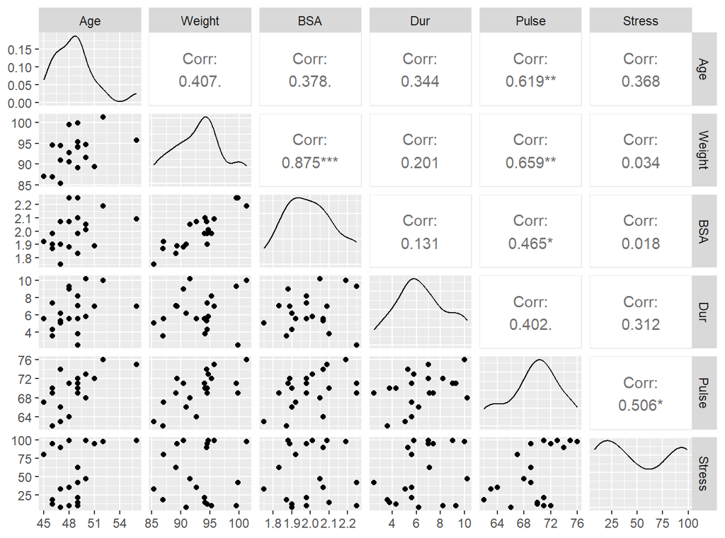

```r
bp |>
  select(Age, Weight, BSA, Dur, Pulse, Stress) |>  # the six x variables
  ggpairs()                          # scatter plots below, correlations above
```

```r
bp |>
  select(Age, Weight, BSA, Dur, Pulse, Stress) |>  # the six x variables
  cor() |>                           # the correlation matrix
  round(2)                           # two decimals. Weight and BSA: 0.88
```

```
#>         Age Weight  BSA  Dur Pulse Stress
#> Age    1.00   0.41 0.38 0.34  0.62   0.37
#> Weight 0.41   1.00 0.88 0.20  0.66   0.03
#> BSA    0.38   0.88 1.00 0.13  0.46   0.02
#> Dur    0.34   0.20 0.13 1.00  0.40   0.31
#> Pulse  0.62   0.66 0.46 0.40  1.00   0.51
#> Stress 0.37   0.03 0.02 0.31  0.51   1.00
```

The **variance inflation factor (VIF)**, one per $x$: 1 means no correlation with the others, above 5 is a worry, above 10 is serious.

```r
vif(fit6)                            # variance inflation factor, one per x
```

```
#>      Age   Weight      BSA      Dur    Pulse   Stress
#> 1.762807 8.417035 5.328751 1.237309 4.413575 1.834845
```

Weight (8.4) and BSA (5.3) are above 5. Removing one of the pair is the simplest remedy:

```r
# the same model without BSA
fit5 <- lm(BP ~ Age + Weight + Dur + Pulse + Stress, data = bp)
vif(fit5)                            # all VIFs now below 5
```

```
#>      Age   Weight      Dur    Pulse   Stress
#> 1.659637 2.256150 1.235620 3.599913 1.739641
```

```r
glance(fit5)                         # adjusted R-squared 0.992: almost nothing lost
```

```
#> # A tibble: 1 × 12
#>   r.squared adj.r.squared   sigma statistic    p.value    df  logLik    AIC
#>       <dbl>         <dbl>   <dbl>     <dbl>      <dbl> <dbl>   <dbl>  <dbl>
#> 1   0.99446       0.99248 0.47080    502.50 2.8355e-15     5 -9.7454 33.491
#> # ℹ 4 more variables: BIC <dbl>, deviance <dbl>, df.residual <int>, nobs <int>
```

Other remedies: combine the two into one index when that makes sense, or use regularisation, such as ridge regression, which keeps all variables but shrinks their estimates. Multicollinearity is a problem for interpreting the estimates, not for predicting.

# 6 Logistic regression

When $y$ has two values, coded 1 (yes) and 0 (no), a straight line predicts values below 0 and above 1, which cannot be probabilities. **Logistic regression** predicts the **probability** that $y = 1$, always between 0 and 1, on an S-shaped curve.

The data are `mtcars`, 32 cars that come with R. `am` is 1 for a manual gearbox and 0 for an automatic; `wt` is the weight in 1000 lbs.

```r
glimpse(mtcars)                      # 32 cars, 11 columns
```

```
#> Rows: 32
#> Columns: 11
#> $ mpg  <dbl> 21.0, 21.0, 22.8, 21.4, 18.7, 18.1, 14.3, 24.4, 22.8, 19.2, 17.8,…
#> $ cyl  <dbl> 6, 6, 4, 6, 8, 6, 8, 4, 4, 6, 6, 8, 8, 8, 8, 8, 8, 4, 4, 4, 4, 8,…
#> $ disp <dbl> 160.0, 160.0, 108.0, 258.0, 360.0, 225.0, 360.0, 146.7, 140.8, 16…
#> $ hp   <dbl> 110, 110, 93, 110, 175, 105, 245, 62, 95, 123, 123, 180, 180, 180…
#> $ drat <dbl> 3.90, 3.90, 3.85, 3.08, 3.15, 2.76, 3.21, 3.69, 3.92, 3.92, 3.92,…
#> $ wt   <dbl> 2.620, 2.875, 2.320, 3.215, 3.440, 3.460, 3.570, 3.190, 3.150, 3.…
#> $ qsec <dbl> 16.46, 17.02, 18.61, 19.44, 17.02, 20.22, 15.84, 20.00, 22.90, 18…
#> $ vs   <dbl> 0, 0, 1, 1, 0, 1, 0, 1, 1, 1, 1, 0, 0, 0, 0, 0, 0, 1, 1, 1, 1, 0,…
#> $ am   <dbl> 1, 1, 1, 0, 0, 0, 0, 0, 0, 0, 0, 0, 0, 0, 0, 0, 0, 1, 1, 1, 0, 0,…
#> $ gear <dbl> 4, 4, 4, 3, 3, 3, 3, 4, 4, 4, 4, 3, 3, 3, 3, 3, 3, 4, 4, 4, 3, 3,…
#> $ carb <dbl> 4, 4, 1, 1, 2, 1, 4, 2, 2, 4, 4, 3, 3, 3, 4, 4, 4, 1, 2, 1, 1, 2,…
```

```r
# glm() with family = binomial is logistic regression
logit <- glm(am ~ wt, data = mtcars, family = binomial)
summary(logit)                       # wt: -4.02, p = 0.005
```

```
#>
#> Call:
#> glm(formula = am ~ wt, family = binomial, data = mtcars)
#>
#> Coefficients:
#>             Estimate Std. Error z value Pr(>|z|)
#> (Intercept)   12.040      4.510   2.670  0.00759 **
#> wt            -4.024      1.436  -2.801  0.00509 **
#> ---
#> Signif. codes:  0 '***' 0.001 '**' 0.01 '*' 0.05 '.' 0.1 ' ' 1
#>
#> (Dispersion parameter for binomial family taken to be 1)
#>
#>     Null deviance: 43.230  on 31  degrees of freedom
#> Residual deviance: 19.176  on 30  degrees of freedom
#> AIC: 23.176
#>
#> Number of Fisher Scoring iterations: 6
```

Read the sign: $-4.02$, so heavier cars are **less likely** to be manual. The p-value, 0.005, is below 0.05: weight is significant. The size of the estimate is on the log-odds scale, which is hard to read, so we use predicted probabilities instead.

[figure not shown]

`type = "response"` gives the probability. With a **cut-off of 0.5**, a probability above 0.5 predicts 1 (manual), otherwise 0. `if_else(test, value if TRUE, value if FALSE)` does this row by row.

```r
cars <- mtcars |>
  mutate(prob = predict(logit, type = "response"),  # type = "response" gives probabilities
         pred = if_else(prob > 0.5, 1, 0))          # cut-off 0.5: above it, predict manual

cars |>
  select(wt, am, prob, pred) |>      # the columns we need
  head()                             # first six cars
```

```
#>                      wt am      prob pred
#> Mazda RX4         2.620  1 0.8172115    1
#> Mazda RX4 Wag     2.875  1 0.6157283    1
#> Datsun 710        2.320  1 0.9373069    1
#> Hornet 4 Drive    3.215  0 0.2897304    0
#> Hornet Sportabout 3.440  0 0.1415972    0
#> Valiant           3.460  0 0.1320944    0
```

```r
# a car of 3000 lbs: probability 0.49
predict(logit, newdata = tibble(wt = 3), type = "response")
```

```
#>         1
#> 0.4921156
```

The **confusion matrix** counts the actual classes against the predicted ones: true positives and true negatives are correct; a false positive is a false alarm, a false negative a missed yes. **Accuracy** is the share of correct predictions.

```r
cars |>
  count(am, pred)                    # the confusion matrix: actual am against predicted
```

```
#>   am pred  n
#> 1  0    0 18
#> 2  0    1  1
#> 3  1    0  2
#> 4  1    1 11
```

```r
cars |>
  summarise(accuracy = mean(am == pred))  # share predicted correctly: 0.91 (29 of 32)
```

```
#>   accuracy
#> 1  0.90625
```

These are the same 32 cars the model learned from. A fair check uses new data.

# 7 k-nearest neighbours, and train and test

**k-nearest neighbours (kNN)** predicts a new case from the $k$ most similar cases we already know. The idea: similar things are close together. kNN fits no line; it keeps the data and compares. The four steps:

1. **Choose $k$**, the number of neighbours.
2. **Measure the distance** from the new point to every known point. The Euclidean distance is the straight-line distance, as with a ruler: $d = \sqrt{(x_1 - x_1')^2 + (x_2 - x_2')^2}$.
3. **Take the $k$ closest.**
4. **Vote**: for classification, the new point gets the most common class among them; for regression, the average of their values.

## 7.1 Example: which T-shirt size for a new customer?

We know the height, weight and T-shirt size of 18 customers. A new customer is 162 cm and 58 kg. We compute the distance from the new customer to every known customer and keep the five closest ($k = 5$).

```r
shirts <- tibble(
  height = c(158, 158, 158, 160, 160, 163, 163, 160, 163,
             165, 165, 165, 168, 168, 168, 170, 170, 170),  # height in cm
  weight = c(58, 59, 63, 59, 60, 60, 61, 64, 64,
             61, 62, 65, 62, 63, 66, 63, 64, 68),            # weight in kg
  size   = c("M", "M", "M", "M", "M", "M", "M", "L", "L",
             "L", "L", "L", "L", "L", "L", "L", "L", "L"))   # T-shirt size

shirts |>
  mutate(distance = sqrt((height - 162)^2 +
                         (weight - 58)^2)) |>  # distance to the new customer
  arrange(distance) |>               # closest first
  slice_head(n = 5)                  # the 5 nearest (k = 5)
```

```
#> # A tibble: 5 × 4
#>   height weight size  distance
#>    <dbl>  <dbl> <chr>    <dbl>
#> 1    160     59 M       2.2361
#> 2    163     60 M       2.2361
#> 3    160     60 M       2.8284
#> 4    163     61 M       3.1623
#> 5    158     58 M       4
```

All five nearest customers wear M, so we predict size **M** for the new customer.

## 7.2 Example: kNN for a number

| Experience (years) | Income (1000 dollars) | Distance to 5 years |
| --- | --- | --- |
| 1 | 25 | 4 |
| 2 | 28 | 3 |
| **4** | **45** | **1** |
| **6** | **60** | **1** |
| **7** | **65** | **2** |

For a new person with 5 years of experience and $k = 3$, the three nearest are 4, 6 and 7 years. The prediction is the average of their incomes: $(45 + 60 + 65) / 3 = 56.7$, so 56,700 dollars.

## 7.3 Train and test

The model learns from the **training set**, usually 80% of the rows chosen at random, like studying past exam questions. It then predicts the **test set**, the other 20%, like a new exam, and we compare with the true values. On the data it learned from, a model can look perfect because it has memorised them; only new data show whether it generalises.

The data for the R example are `iris`, 150 flowers of three species that come with R.

```r
flowers <- iris |>
  mutate(id = row_number())          # a number for every flower, to split by

set.seed(2026)                       # makes the random split the same every time
train <- flowers |>
  slice_sample(prop = 0.8)           # a random 80%: 120 flowers
test <- flowers |>
  anti_join(train, by = "id")        # the other 20%: 30 flowers
```

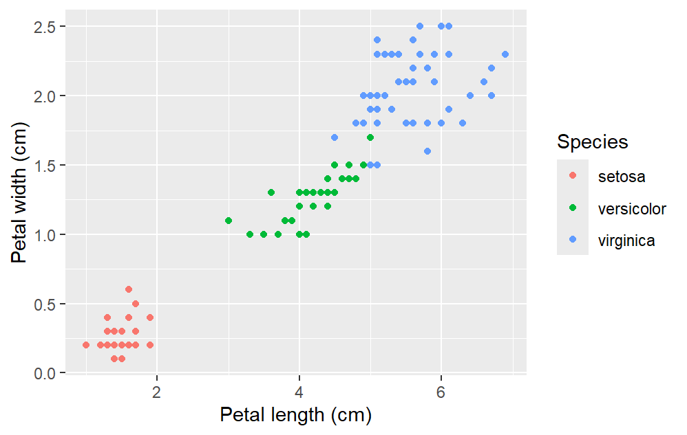

```r
ggplot(train, aes(x = Petal.Length, y = Petal.Width, colour = Species)) +
  geom_point() +                     # the training flowers
  labs(x = "Petal length (cm)", y = "Petal width (cm)")
```

`knn()` takes the $x$ columns of the training and test rows, the true classes of the training rows (`cl`), and $k$.

```r
train_x <- train |>
  select(Petal.Length, Petal.Width)  # the x variables of the training flowers
test_x <- test |>
  select(Petal.Length, Petal.Width)  # the x variables of the test flowers

set.seed(2026)                       # knn() breaks ties at random
# k = 5 neighbours
pred5 <- knn(train = train_x, test = test_x, cl = train$Species, k = 5)

test <- test |>
  mutate(pred = pred5)               # add the predicted species to the test table
test |>
  count(Species, pred)               # the confusion matrix
```

```
#>      Species       pred  n
#> 1     setosa     setosa 13
#> 2 versicolor versicolor 13
#> 3 versicolor  virginica  1
#> 4  virginica  virginica  3
```

```r
test |>
  summarise(accuracy = mean(Species == pred))  # share of test flowers classified correctly
```

```
#>    accuracy
#> 1 0.9666667
```

29 of the 30 test flowers are classified correctly: accuracy 0.97 on flowers the method had not seen. The one error is a versicolor taken for a virginica.

**Choosing $k$.** A small $k$ follows every single point, including noise: overfitting. A large $k$ smooths too much: underfitting. Try several values and keep the one with the best test accuracy; an odd $k$ avoids ties between two classes. **Units matter**: kNN works with distances, so put the $x$ variables on the same scale first when they are in different units. Petal length and width are both in cm.

# 8 The three methods side by side

|  | Multiple linear regression | Logistic regression | k-nearest neighbours |
| --- | --- | --- | --- |
| $y$ is | a number | yes or no (1 or 0) | a class or a number |
| It gives | a predicted number | a probability, then a class | the majority class or the average |
| In R | `lm()` | `glm(family = binomial)` | `knn()` |
| We read | $\beta$s, p-values, adjusted $R^2$ | signs, p-values, probabilities | accuracy on the test set |